# IODS course project

Herman Savinen

# About the project

Trying to learn some open data science

(https://github.com/hsavinen/IODS-project/)

# Linear regression

*This week I have practised data wrangling techniques and learned how to implement and evaluate linear regression models.*

Starting off with importing two libraries for data visualisation and and reading the analysis dataset into R-dataframe.

```r
library(GGally)
library(ggplot2)

learning2014 <- read.csv("C:/Users/Admin/Documents/GitHub/IODS-project/data/learning2014.csv")
```

The structure and dimensions of the data can be explored using R’s str() -function.

```r
str(learning2014)
```

```
## 'data.frame':    166 obs. of  7 variables:
##  $ gender  : Factor w/ 2 levels "F","M": 1 2 1 2 2 1 2 1 2 1 ...
##  $ Age     : int  53 55 49 53 49 38 50 37 37 42 ...
##  $ Attitude: num  3.7 3.1 2.5 3.5 3.7 3.8 3.5 2.9 3.8 2.1 ...
##  $ Deep    : num  3.75 2.88 3.88 3.5 3.75 ...
##  $ Stra    : num  3.38 2.75 3.62 3.12 3.62 ...
##  $ Surf    : num  2.58 3.17 2.25 2.25 2.83 ...
##  $ Points  : int  25 12 24 10 22 21 21 31 24 26 ...
```

The data originates from an international survey of approaches to learning and holds 166 observations of 7 variables. Following variables have been combined from several answers:

- Deep, measuring deep learning approach
- Stra, measuring strategic learning approach
- Surf, measuring surface learning approach

Summaries and a graphical overview provide a convenient way to further inspect the data and to spot possible relationships between variables.

```r
summary(learning2014)
```

```
##  gender       Age           Attitude          Deep            Stra
##  F:110   Min.   :17.00   Min.   :1.400   Min.   :1.625   Min.   :1.250
##  M: 56   1st Qu.:21.00   1st Qu.:2.600   1st Qu.:3.500   1st Qu.:2.625
##          Median :22.00   Median :3.200   Median :3.875   Median :3.188
##          Mean   :25.51   Mean   :3.143   Mean   :3.796   Mean   :3.121
##          3rd Qu.:27.00   3rd Qu.:3.700   3rd Qu.:4.250   3rd Qu.:3.625
##          Max.   :55.00   Max.   :5.000   Max.   :4.875   Max.   :5.000
##       Surf           Points
##  Min.   :1.583   Min.   : 7.00
##  1st Qu.:2.417   1st Qu.:19.00
##  Median :2.833   Median :23.00
##  Mean   :2.787   Mean   :22.72
##  3rd Qu.:3.167   3rd Qu.:27.75
##  Max.   :4.333   Max.   :33.00
```

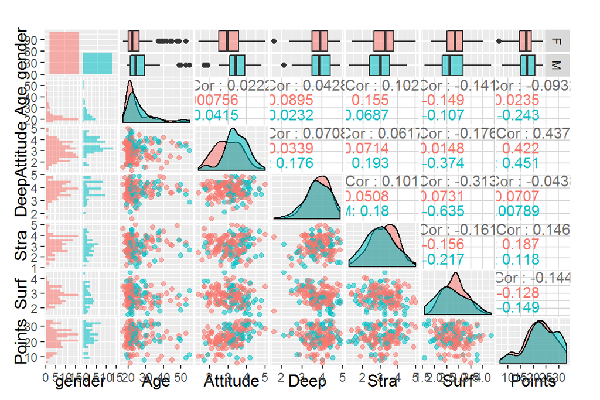

```r
p <- ggpairs(learning2014, mapping = aes(col = gender, alpha = 0.3), lower = list(combo = wrap("facethist", bins = 20)))
p
```

As we can see, the variables seem reasonably normally distributed, excluding age. Using different colors for genders in plotting could reveal some differences, but it must be noted that there are considerably less males in the data.

Judging from the scatterplots and correlations, attitude and strategic and surface learning approaches could be associated with exam points. A linear regression model with points as a dependent variable can be used to assess if these three variables predict the exam points.

Fitting the regression model.

```r
regression_model <- lm(Points ~ Attitude + Stra + Surf, data = learning2014)
summary(regression_model)
```

```
##
## Call:
## lm(formula = Points ~ Attitude + Stra + Surf, data = learning2014)
##
## Residuals:
##      Min       1Q   Median       3Q      Max
## -17.1550  -3.4346   0.5156   3.6401  10.8952
##
## Coefficients:
##             Estimate Std. Error t value Pr(>|t|)
## (Intercept)  11.0171     3.6837   2.991  0.00322 **
## Attitude      3.3952     0.5741   5.913 1.93e-08 ***
## Stra          0.8531     0.5416   1.575  0.11716
## Surf         -0.5861     0.8014  -0.731  0.46563
## ---
## Signif. codes:  0 '***' 0.001 '**' 0.01 '*' 0.05 '.' 0.1 ' ' 1
##
## Residual standard error: 5.296 on 162 degrees of freedom
## Multiple R-squared:  0.2074, Adjusted R-squared:  0.1927
## F-statistic: 14.13 on 3 and 162 DF,  p-value: 3.156e-08
```

The summary of the model holds the significance tests of the coefficents. The p-values show that Attitude variable is the only one having a statistically significant relationship with the dependent variable, null hypothesis being that the value of the parameter is zero.

Fitting the model again with Attitude as the explanatory variable.

```r
regression_model <- lm(Points ~ Attitude, data = learning2014)
summary(regression_model)
```

```
##
## Call:
## lm(formula = Points ~ Attitude, data = learning2014)
##
## Residuals:
##      Min       1Q   Median       3Q      Max
## -16.9763  -3.2119   0.4339   4.1534  10.6645
##
## Coefficients:
##             Estimate Std. Error t value Pr(>|t|)
## (Intercept)  11.6372     1.8303   6.358 1.95e-09 ***
## Attitude      3.5255     0.5674   6.214 4.12e-09 ***
## ---
## Signif. codes:  0 '***' 0.001 '**' 0.01 '*' 0.05 '.' 0.1 ' ' 1
##
## Residual standard error: 5.32 on 164 degrees of freedom
## Multiple R-squared:  0.1906, Adjusted R-squared:  0.1856
## F-statistic: 38.61 on 1 and 164 DF,  p-value: 4.119e-09
```

Now we have a simple linear regression model. As mentioned above, Attitude has a statistically significant relationship with exam points. Multiple R-squared tells how much of the variance of the dependent variable is explained by the model. 0.1906 is quite low as the scale ranges from 0 to 1, but quite expected as the model holds only one explanatory variable. It should be addes, that in many research fields, especially involving human behaviour and other complex and hard to predict phenomena, the R-squared values are seldom very high.

The question of model validation has to do with the assumptions of the model and how well they fit reality. Linear regression has following important assumprions:

- The errors are normally distributed
- The errors are not correlated
- The errors have constant variance

Drawing diagnostic plots to validate the model.

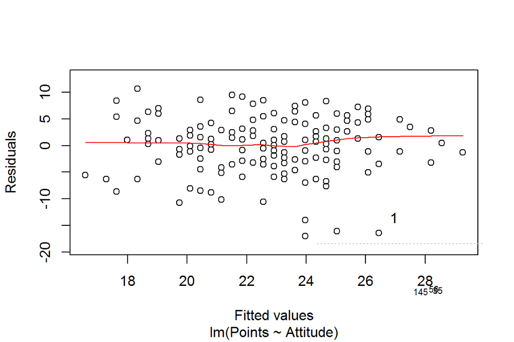

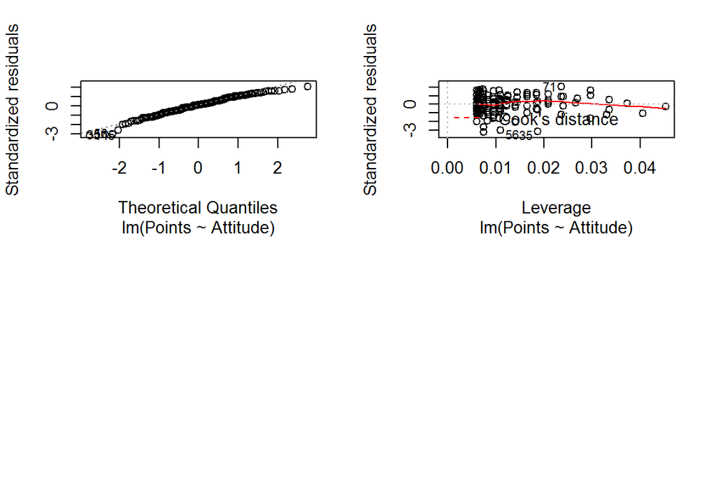

```r
plot(regression_model, which = c(1,2,5), par(mfrow = c(2,2)))
```

Conclusions from the diagnostic plots:

- No pattern is observable in the scatter plot showing residuals and fitted values. This implies that the constant variance assumptions holds, so the errors are independent.
- The QQ-plot has the residuals falling reasonably well on the line. Normality assumprions seems to be met.
- Lastly, reiduals vs leverage plot has no outliers with much leverage on the model.

# Logistic regression

```r
library(ggplot2)
library(GGally)
library(tidyr)
library(dplyr)
alc <- read.table("http://s3.amazonaws.com/assets.datacamp.com/production/course_2218/datasets/alc.txt", sep = ',', header = TRUE)

colnames(alc)
```

```
##  [1] "school"     "sex"        "age"        "address"    "famsize"
##  [6] "Pstatus"    "Medu"       "Fedu"       "Mjob"       "Fjob"
## [11] "reason"     "nursery"    "internet"   "guardian"   "traveltime"
## [16] "studytime"  "failures"   "schoolsup"  "famsup"     "paid"
## [21] "activities" "higher"     "romantic"   "famrel"     "freetime"
## [26] "goout"      "Dalc"       "Walc"       "health"     "absences"
## [31] "G1"         "G2"         "G3"         "alc_use"    "high_use"
```

These are the variables present in the data, which has been joined from two surveys on student alchol consumption in Portugal. Those students that were not present in both datasets have been excluded and the variables not used for joining the two data have been combined by averaging. These completely new variables have been calculated:

- ‘alc_use’ is the average of workday and weekend alchol use (‘Dalc’ and ‘Walc’)
- ‘high_use’ is TRUE if ‘alc_use’ is higher than 2 and FALSE otherwise

I have chosen 4 variables that I would assume to have a relatisonship with alcohol use:

- ‘sex’ as males to my understanding tend to consume more alchol in most societies.
- ‘abscenses’, which refers to absences from school. Students could skip school to go drinking instead, or possibly to deal with hangover.
- ‘goout’ (going out with friends) should be associated with higher alcohol consumption as drinking is a social event for most.
- ‘G3’ (final grade). Spending more time drinking could result in spending less time studying, which could be reflected in students success in school.

Let’s graphically explore the chosen variabes and their relationship with alchol consumption. Starting off with final grades.

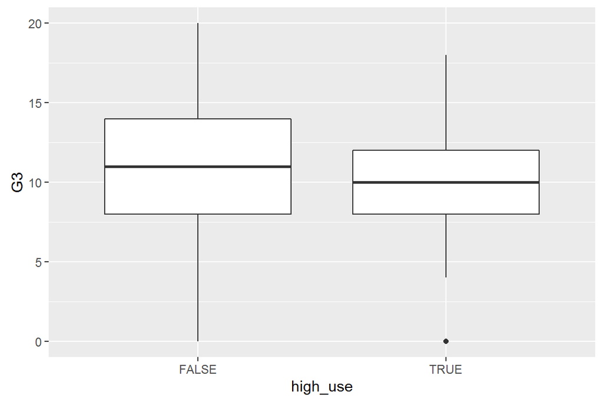

```r
g1 <- ggplot(alc, aes(x = high_use, y = G3))
g1 +  geom_boxplot()
```

So it seems like those students with high alcohol consumption have lower grades. On the other hand the difference doesen’t seem to be very large, so it could be that this isn’t statistically significant.

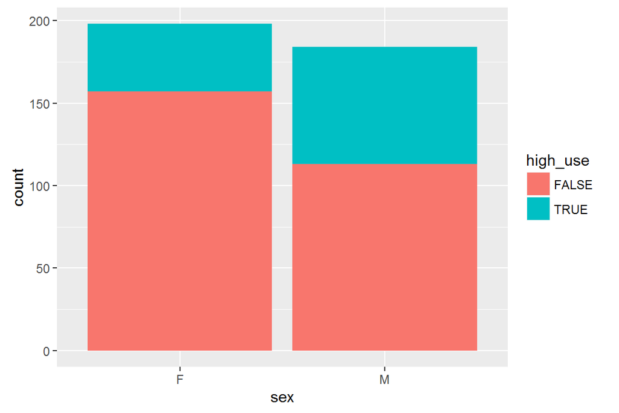

```r
g2 <-ggplot(data = alc, aes(x = sex))
g2 + geom_bar(aes(fill = high_use))
```

As expected, males definently have more high use cases.

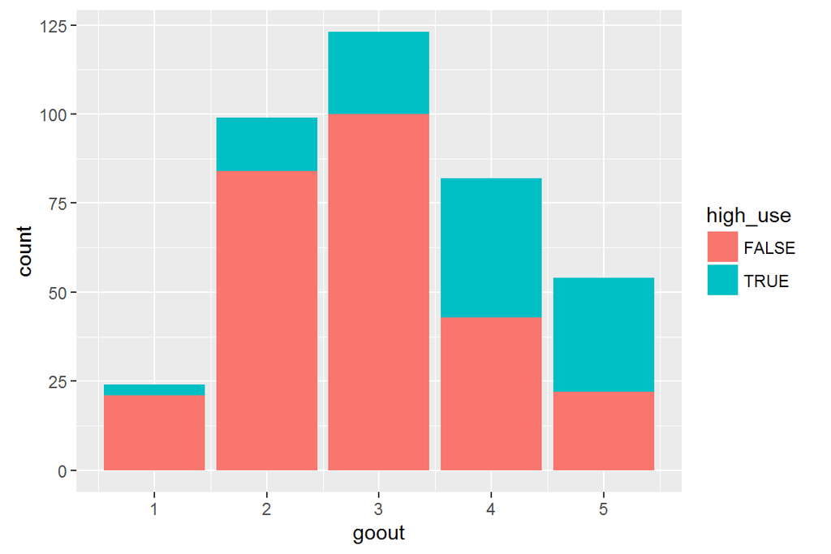

```r
g3 <-ggplot(data = alc, aes(x = goout))
g3 + geom_bar(aes(fill = high_use))
```

Going out with friends seems to fit well my hypothesis, proportion of high users grows with it.

High users also have more absences as shown below.

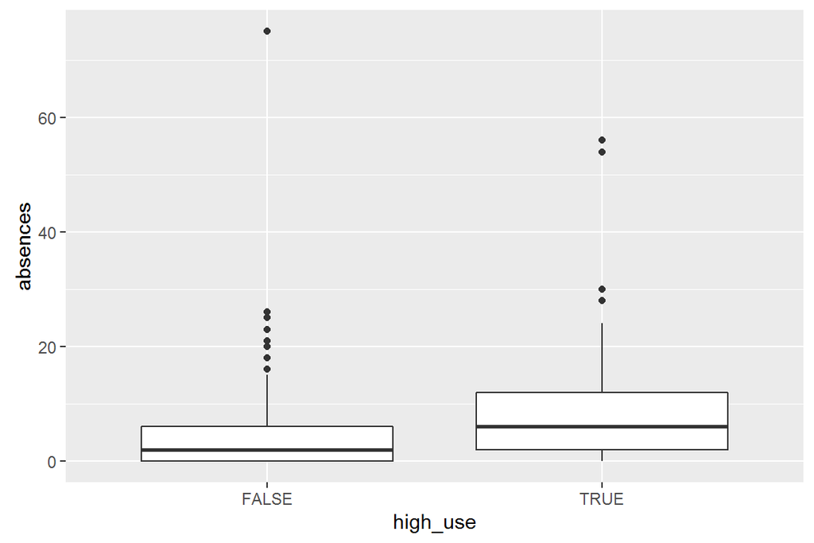

```r
g4 <- ggplot(data = alc, aes(x = high_use, y = absences))
g4 + geom_boxplot()
```

To explore the relationship between these variables and the binary high/low alcohol consumption variable as the target variable, a logistic regression model is used.

```r
m <- glm(high_use ~ goout + absences + sex + G3, data = alc, family = "binomial")
summary(m)
```

```
##
## Call:
## glm(formula = high_use ~ goout + absences + sex + G3, family = "binomial",
##     data = alc)
##
## Deviance Residuals:
##     Min       1Q   Median       3Q      Max
## -1.8324  -0.7898  -0.5309   0.7984   2.4577
##
## Coefficients:
##              Estimate Std. Error z value Pr(>|z|)
## (Intercept) -4.167962   0.592392  -7.036 1.98e-12 ***
## goout        0.743240   0.122221   6.081 1.19e-09 ***
## absences     0.066193   0.017007   3.892 9.94e-05 ***
## sexM         1.007632   0.259143   3.888 0.000101 ***
## G3          -0.007484   0.028174  -0.266 0.790524
## ---
## Signif. codes:  0 '***' 0.001 '**' 0.01 '*' 0.05 '.' 0.1 ' ' 1
##
## (Dispersion parameter for binomial family taken to be 1)
##
##     Null deviance: 462.21  on 381  degrees of freedom
## Residual deviance: 381.37  on 377  degrees of freedom
## AIC: 391.37
##
## Number of Fisher Scoring iterations: 4
```

The summary of the model shows that the final grades (G3) coefficent is not signigicant. To further interpret this model, it is necessary to have a look at the coefficents as odds ratios and se the confidence interwalls for them.

```r
OR <- coef(m) %>% exp
CI <- confint(m) %>% exp
cbind(OR, CI)
```

```
##                     OR       2.5 %     97.5 %
## (Intercept) 0.01548378 0.004596028 0.04711571
## goout       2.10273750 1.665074537 2.69153538
## absences    1.06843253 1.035731967 1.10810561
## sexM        2.73910700 1.659092250 4.59251217
## G3          0.99254399 0.939587311 1.04966040
```

In the case of G3 variable, the confidence interval of odds ratio includes 1, which means that a change in the final grade doesn’t affect the odds of having high alcohol consumption. Therefore it doesn’t have a statistical relatioship with alchohol use in this data. G3 variable is now dropped as the next task is to see the predictive power of this model.

```r
m <- glm(high_use ~ goout + absences + sex, data = alc, family = "binomial")
probabilities <- predict(m, type = "response")
alc <- mutate(alc, probability = probabilities)
alc <- mutate(alc, prediction = probability > 0.5)
```

Predictions are evaluated below. Predictions and real values are cross tabulated for easy comparison. The [1] is the average number of incorrect predictions.

```r
table(high_use = alc$high_use, prediction = alc$prediction)
```

```
##         prediction
## high_use FALSE TRUE
##    FALSE   255   15
##    TRUE     66   46
```

```r
loss_func <- function(class, prob) {
  n_wrong <- abs(class - prob) > 0.5
  mean(n_wrong)
}

loss_func(class = alc$high_use, prob = alc$probability)
```

```
## [1] 0.2120419
```

The model predicts low alchol consumption fairly well but doesn’t quite pick up those high consmuption cases.